# Capstone Quiz I

Complete all **Exercises**, and submit answers to **Questions** on the Coursera platform.

This initial quiz will concern exploratory data analysis (EDA) of the Ames Housing dataset. EDA is essential when working with any source of data and helps inform modeling.

First, let us load the data:

```r
library(devtools)
library(dplyr)
```

```r
library(statsr)
library(ggplot2)
library(gridExtra)
load("ames_train.Rdata")
```

1. Which of the following are the three variables with the highest number of missing observations?
   1. `Misc.Feature`, `Fence`, `Pool.QC`
   2. `Misc.Feature`, `Alley`, `Pool.QC`
   3. `Pool.QC`, `Alley`, `Fence`
   4. `Fireplace.Qu`, `Pool.QC`, `Lot.Frontage`

Ans: `Misc.Feature`, `Alley`, `Pool.QC`

```r
colSums(is.na(ames_train))[c("Alley", "Misc.Feature", "Fence", "Pool.QC", "Fireplace.Qu", "Lot.Frontage")]
```

```
##        Alley Misc.Feature        Fence      Pool.QC Fireplace.Qu
##          933          971          798          997          491
## Lot.Frontage
##          167
```

2. How many categorical variables are coded in R as having type `int`? Change them to factors when conducting your analysis.
   1. 0
   2. 1
   3. 2
   4. 3

Ans: 2

```r
#Filtering only the numeric columns
str(ames_train[sapply(ames_train,is.numeric)])
```

```
## Classes 'tbl_df', 'tbl' and 'data.frame':    1000 obs. of  38 variables:
##  $ PID            : int  909176150 905476230 911128020 535377150 534177230 908128060 902135020 528228540 923426010 908186050 ...
##  $ area           : int  856 1049 1001 1039 1665 1922 936 1246 889 1072 ...
##  $ price          : int  126000 139500 124900 114000 227000 198500 93000 187687 137500 140000 ...
##  $ MS.SubClass    : int  30 120 30 70 60 85 20 20 20 180 ...
##  $ Lot.Frontage   : int  NA 42 60 80 70 64 60 53 74 35 ...
##  $ Lot.Area       : int  7890 4235 6060 8146 8400 7301 6000 3710 12395 3675 ...
##  $ Overall.Qual   : int  6 5 5 4 8 7 4 7 5 6 ...
##  $ Overall.Cond   : int  6 5 9 8 6 5 4 5 6 5 ...
##  $ Year.Built     : int  1939 1984 1930 1900 2001 2003 1953 2007 1984 2005 ...
##  $ Year.Remod.Add : int  1950 1984 2007 2003 2001 2003 1953 2008 1984 2005 ...
##  $ Mas.Vnr.Area   : int  0 149 0 0 0 500 0 20 0 76 ...
##  $ BsmtFin.SF.1   : int  238 552 737 0 643 0 0 0 647 467 ...
##  $ BsmtFin.SF.2   : int  0 393 0 0 0 0 0 0 0 0 ...
##  $ Bsmt.Unf.SF    : int  618 104 100 405 167 0 936 1146 217 80 ...
```

[output cut: 24 more lines]

3. In terms of price, which neighborhood has the highest standard deviation?
   1. `StoneBr`
   2. `Timber`
   3. `Veenker`
   4. `NridgHt`

Ans: StoneBr

```r
ames_train %>% group_by(Neighborhood) %>% summarise(SD_price = sd(price)) %>% arrange(desc(SD_price))
```

```
## # A tibble: 27 x 2
##    Neighborhood  SD_price
##          <fctr>     <dbl>
##  1      StoneBr 123459.10
##  2      NridgHt 105088.90
##  3       Timber  84029.57
##  4      Veenker  72545.41
##  5      Crawfor  71267.56
##  6      GrnHill  70710.68
##  7      Somerst  65199.49
##  8      Edwards  54851.63
##  9      CollgCr  52786.08
## 10      SawyerW  48354.36
## # ... with 17 more rows
```

4. Using scatter plots or other graphical displays, which of the following variables appears to be the best single predictor of `price`?
   1. `Lot.Area`
   2. `Bedroom.AbvGr`
   3. `Overall.Qual`
   4. `Year.Built`

Ans: Overall.Qual

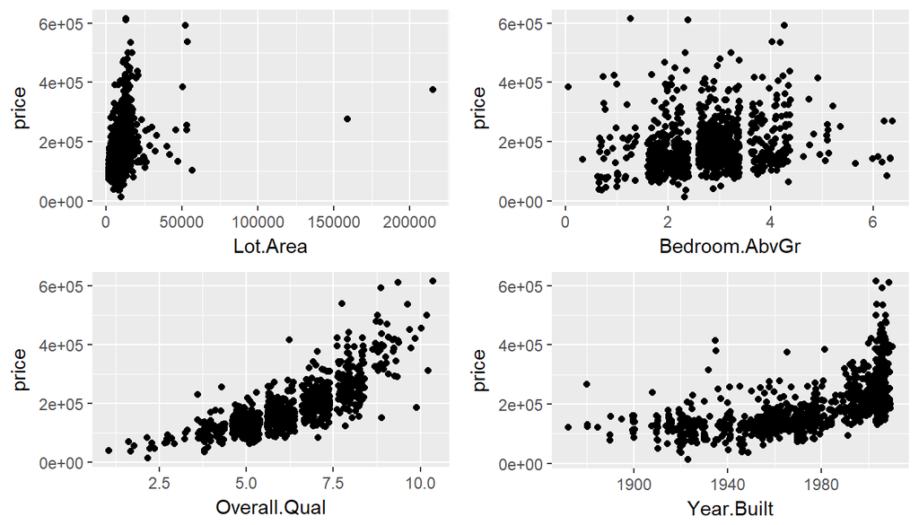

```r
pA <- ggplot(data = ames_train, aes(y = price, x = Lot.Area)) + geom_jitter()
pB <- ggplot(data = ames_train, aes(y = price, x = Bedroom.AbvGr)) + geom_jitter()
pC <- ggplot(data = ames_train, aes(y = price, x = Overall.Qual)) + geom_jitter()
pD <- ggplot(data = ames_train, aes(y = price, x = Year.Built)) + geom_jitter()
grid.arrange(pA, pB, pC, pD, nrow = 2, ncol = 2)
```

5. Suppose you are examining the relationship between `price` and `area`. Which of the following variable transformations makes the relationship appear to be the most linear?
   1. Do not transform either `price` or `area`
   2. Log-transform `price` but not `area`
   3. Log-transform `area` but not `price`
   4. Log-transform both `price` and `area`

Log-transform both `price` and `area`

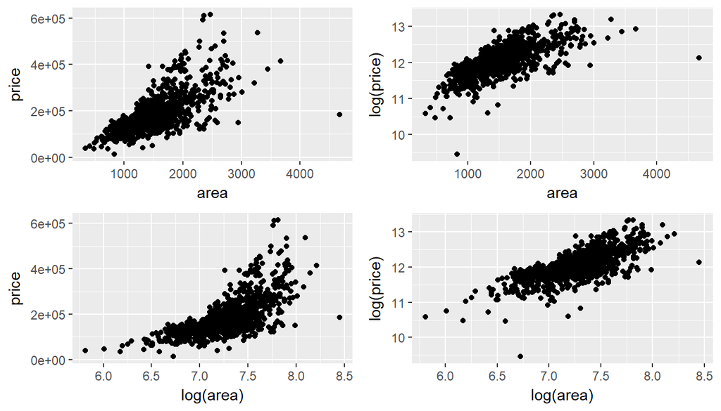

```r
pA <- ggplot(data = ames_train, aes(y = price, x = area)) + geom_point()
pB <- ggplot(data = ames_train, aes(y = log(price), x = area)) + geom_point()
pC <- ggplot(data = ames_train, aes(y = price, x = log(area))) + geom_point()
pD <- ggplot(data = ames_train, aes(y = log(price), x = log(area))) + geom_point()
grid.arrange(pA, pB, pC, pD, nrow = 2, ncol = 2)
```

6. Suppose that your prior for the proportion of houses that have at least one garage is Beta(9, 1). What is your posterior? Assume a beta-binomial model for this proportion.
   1. Beta(954, 46)
   2. Beta(963, 46)
   3. Beta(954, 47)
   4. Beta(963, 47)

Ans: Beta(963, 47)

```r
ames_train %>% filter(is.na(Garage.Type)) %>% summarise(noGarage = n())
```

```
## # A tibble: 1 x 1
##   noGarage
##      <int>
## 1       46
```

```r
ames_train %>% filter(!is.na(Garage.Type)) %>% summarise(Garage = n())
```

```
## # A tibble: 1 x 1
##   Garage
##    <int>
## 1    954
```

7. Which of the following statements is true about the dataset?
   1. Over 30 percent of houses were built after the year 1999.
   2. The median housing price is greater than the mean housing price.
   3. 21 houses do not have a basement.
   4. 4 houses are located on gravel streets.

Ans:21 houses do not have a basement.

```r
ames_train %>% summarise(totalcount= n(), later1999 = sum( Year.Built >1999))
```

```
## # A tibble: 1 x 2
##   totalcount later1999
##        <int>     <int>
## 1       1000       272
```

```r
summary(ames_train$price)
```

```
##    Min. 1st Qu.  Median    Mean 3rd Qu.    Max.
##   12789  129763  159467  181190  213000  615000
```

```r
ames_train %>% filter(is.na(Bsmt.Qual)) %>% summarise(NoBasement = n())
```

```
## # A tibble: 1 x 1
##   NoBasement
##        <int>
## 1         21
```

8. Test, at the $\alpha = 0.05$ level, whether homes with a garage have larger square footage than those without a garage.
   1. With a p-value near 0.000, we reject the null hypothesis of no difference.
   2. With a p-value of approximately 0.032, we reject the null hypothesis of no difference.
   3. With a p-value of approximately 0.135, we fail to reject the null hypothesis of no difference.
   4. With a p-value of approximately 0.343, we fail to reject the null hypothesis of no difference.

Ans: With a p-value near 0.000, we reject the null hypothesis of no difference

```r
ames_train <- ames_train %>% mutate(garagePresent = ifelse(is.na(Garage.Type), "Yes", "No"))
inference(y = area, x = garagePresent, data = ames_train, statistic = "mean", type = "ht", null = 0,
          alternative = "twosided", conf_level = 0.95, method = "theoretical", order = c("Yes","No"))
```

```
## Response variable: numerical
## Explanatory variable: categorical (2 levels)
## n_Yes = 46, y_bar_Yes = 1145.0435, s_Yes = 445.1805
## n_No = 954, y_bar_No = 1492.6027, s_No = 502.5917
## H0: mu_Yes =  mu_No
## HA: mu_Yes != mu_No
## t = -5.1395, df = 45
## p_value = < 0.0001
```

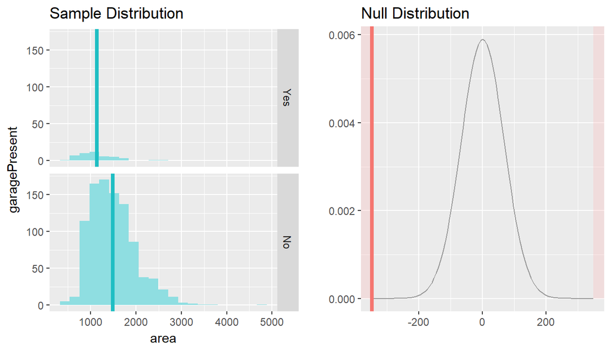

9. For homes with square footage greater than 2000, assume that the number of bedrooms above ground follows a Poisson distribution with rate $\lambda$. Your prior on $\lambda$ follows a Gamma distribution with mean 3 and standard deviation 1. What is your posterior mean and standard deviation for the average number of bedrooms in houses with square footage greater than 2000 square feet?
   1. Mean: 3.61, SD: 0.11
   2. Mean: 3.62, SD: 0.16
   3. Mean: 3.63, SD: 0.09
   4. Mean: 3.63, SD: 0.91

Ans: Mean: 3.62, SD: 0.16

```r
TotalCount<- ames_train %>% filter(area > 2000) %>% nrow()
BedroomsCount <- ames_train %>% filter(area > 2000) %>% select(Bedroom.AbvGr) %>% sum()

old_k <- 9
old_theta <- 1/3

new_k <- old_k + BedroomsCount
new_theta <- old_theta/(old_theta*TotalCount + 1)

new_mean <- new_k*new_theta
new_sd <- new_theta * sqrt(new_k)

new_mean
```

```
## [1] 3.617021
```

```r
new_sd
```

```
## [1] 0.1601644
```

10. When regressing $\log$(`price`) on $\log$(`area`), there are some outliers. Which of the following do the three most outlying points have in common?
    1. They had abnormal sale conditions.
    2. They have only two bedrooms.
    3. They have an overall quality of less than 3.
    4. They were built before 1930.

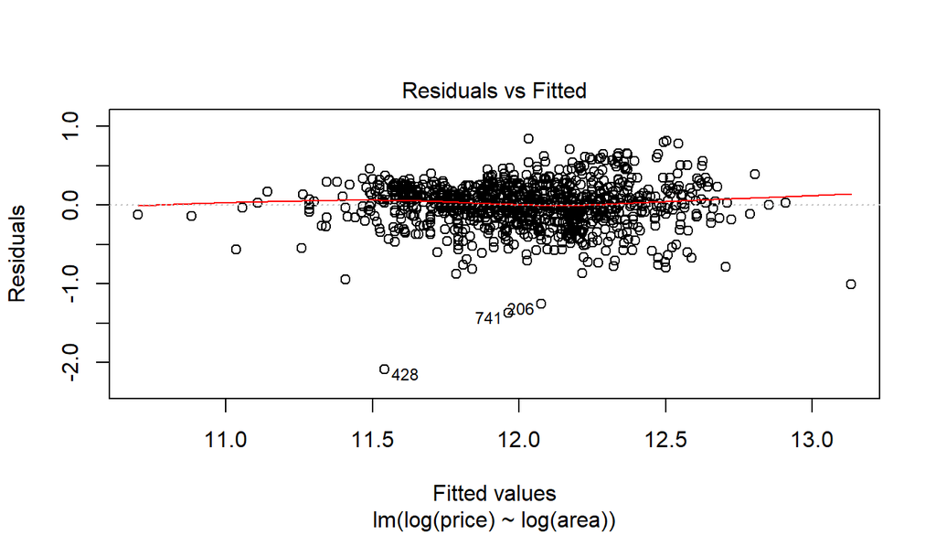

```r
model_lm <- lm(log(price) ~ log(area), data = ames_train)

plot(model_lm, 1)
```

```r
ames_train[c(206,428,741),]
```

```
## # A tibble: 3 x 82
##         PID  area price MS.SubClass MS.Zoning Lot.Frontage Lot.Area Street
##       <int> <int> <int>       <int>    <fctr>        <int>    <int> <fctr>
## 1 903484080  1484 50000          50        RM           60    10320   Pave
## 2 902207130   832 12789          30        RM           68     9656   Pave
## 3 911102170  1317 40000          70   C (all)           50     8500   Pave
## # ... with 74 more variables: Alley <fctr>, Lot.Shape <fctr>,
## #   Land.Contour <fctr>, Utilities <fctr>, Lot.Config <fctr>,
## #   Land.Slope <fctr>, Neighborhood <fctr>, Condition.1 <fctr>,
## #   Condition.2 <fctr>, Bldg.Type <fctr>, House.Style <fctr>,
## #   Overall.Qual <int>, Overall.Cond <int>, Year.Built <int>,
## #   Year.Remod.Add <int>, Roof.Style <fctr>, Roof.Matl <fctr>,
## #   Exterior.1st <fctr>, Exterior.2nd <fctr>, Mas.Vnr.Type <fctr>,
## #   Mas.Vnr.Area <int>, Exter.Qual <fctr>, Exter.Cond <fctr>,
## #   Foundation <fctr>, Bsmt.Qual <fctr>, Bsmt.Cond <fctr>,
## #   Bsmt.Exposure <fctr>, BsmtFin.Type.1 <fctr>, BsmtFin.SF.1 <int>,
## #   BsmtFin.Type.2 <fctr>, BsmtFin.SF.2 <int>, Bsmt.Unf.SF <int>,
## #   Total.Bsmt.SF <int>, Heating <fctr>, Heating.QC <fctr>,
## #   Central.Air <fctr>, Electrical <fctr>, X1st.Flr.SF <int>,
## #   X2nd.Flr.SF <int>, Low.Qual.Fin.SF <int>, Bsmt.Full.Bath <int>,
## #   Bsmt.Half.Bath <int>, Full.Bath <int>, Half.Bath <int>,
## #   Bedroom.AbvGr <int>, Kitchen.AbvGr <int>, Kitchen.Qual <fctr>,
## #   TotRms.AbvGrd <int>, Functional <fctr>, Fireplaces <int>,
## #   Fireplace.Qu <fctr>, Garage.Type <fctr>, Garage.Yr.Blt <int>,
## #   Garage.Finish <fctr>, Garage.Cars <int>, Garage.Area <int>,
## #   Garage.Qual <fctr>, Garage.Cond <fctr>, Paved.Drive <fctr>,
## #   Wood.Deck.SF <int>, Open.Porch.SF <int>, Enclosed.Porch <int>,
## #   X3Ssn.Porch <int>, Screen.Porch <int>, Pool.Area <int>,
## #   Pool.QC <fctr>, Fence <fctr>, Misc.Feature <fctr>, Misc.Val <int>,
## #   Mo.Sold <int>, Yr.Sold <int>, Sale.Type <fctr>, Sale.Condition <fctr>,
## #   garagePresent <chr>
```

11. Which of the following are reasons to log-transform `price` if used as a dependent variable in a linear regression?
    1. `price` is right-skewed.
    2. `price` cannot take on negative values.
    3. `price` can only take on integer values.
    4. Both a and b.

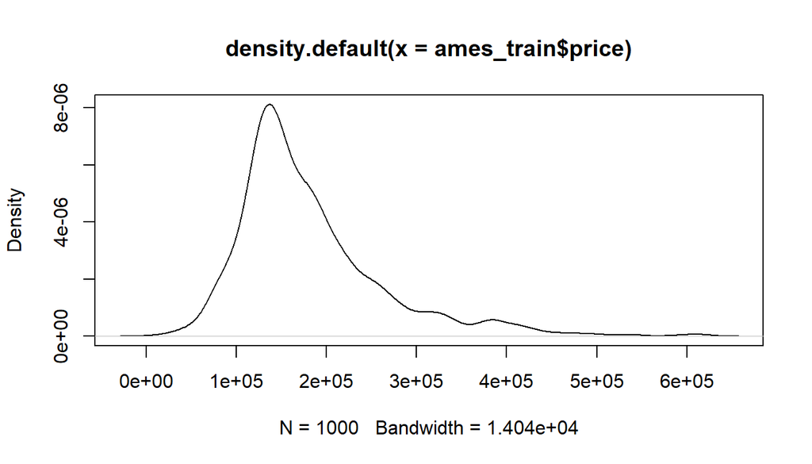

```r
plot(density(ames_train$price))
```

12. How many neighborhoods consist of only single-family homes? (e.g. `Bldg.Type` = `1Fam`)
    1. 0
    2. 1
    3. 2
    4. 3

Ans: 3

```r
ames_train %>% group_by(Neighborhood) %>% summarise(mean(Bldg.Type == "1Fam"))
```

```
## # A tibble: 27 x 2
##    Neighborhood `mean(Bldg.Type == "1Fam")`
##          <fctr>                       <dbl>
##  1      Blmngtn                   0.1818182
##  2      Blueste                   0.0000000
##  3       BrDale                   0.0000000
##  4      BrkSide                   0.9756098
##  5      ClearCr                   1.0000000
##  6      CollgCr                   0.9647059
##  7      Crawfor                   0.8620690
##  8      Edwards                   0.8000000
##  9      Gilbert                   0.9795918
## 10       Greens                   0.0000000
## # ... with 17 more rows
```

13. Using color, different plotting symbols, conditioning plots, etc., does there appear to be an association between $\log$(`area`) and the number of bedrooms above ground (`Bedroom.AbvGr`)?
    1. Yes
    2. No

Ans: Yes

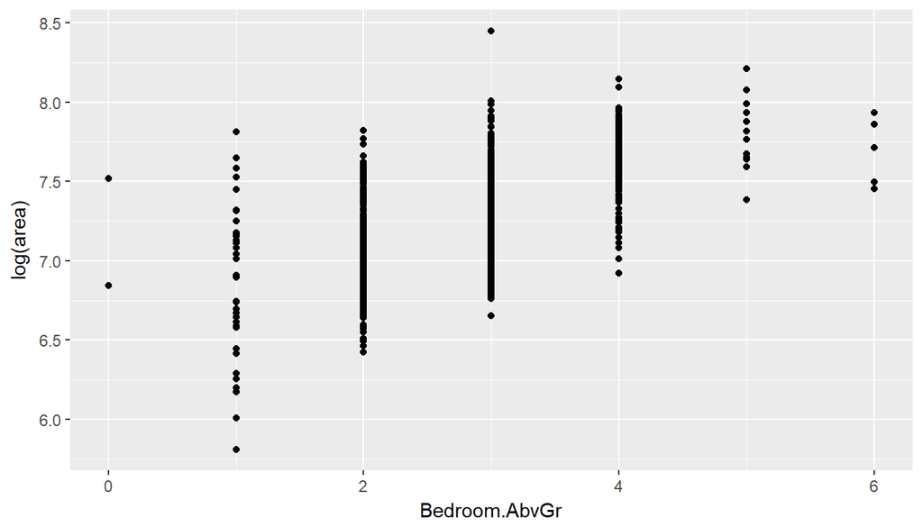

```r
ggplot(data = ames_train, aes(y = log(area), x = Bedroom.AbvGr)) +
  geom_point()
```

14. Of the people who have unfinished basements, what is the average square footage of the unfinished basement?
    1. 590.36
    2. 595.25
    3. 614.37
    4. 681.94

```r
ames_train %>% filter(BsmtFin.Type.2 == 'Unf', BsmtFin.Type.1 == 'Unf', !is.na(Bsmt.Unf.SF)) %>% summarise(mean_area = mean(Bsmt.Unf.SF))
```

```
## # A tibble: 1 x 1
##   mean_area
##       <dbl>
## 1  951.1935
```